# Kinetic analysis of yeast-yeast interactions in oenological conditions

thibault nidelet

02/07/2018

# README

Here you can find the script for all analysis and graphiqual representation of the article “Kinetic analysis of yeast-yeast interactions in oenological conditions”

We used two dataset for our analysis :

- CO2.csv
- all_data.csv

The first dataset (**CO2.csv**) contain the evolution of CO2 production every 20mn up to 300h for each fermentation. The columns are :

- Blocs (the 5 different blocks of the experiment)
- Fermenter (the number of the fermenter of each fermentation. The same fermenters can be found in different blocks)
- Species (the species composition at t0 of each fermentation)
- Time (the time in hours)
- CO2 (the production of CO2 in g/L)
- CO2_rate (the rate of CO2 production in g/L/h)

The second dataset gives population and metabolites concentration for around 10 points across the fermentation. The columns are :

- Blocs (the 5 different blocks of the experiment)
- Fermenter (the number of the fermenter of each fermentation. The same fermenters can be found in different blocks)
- Species (the species composition at t0 of each fermentation)
- Time (the time in hours)
- CO2 (the production of CO2 in g/L)
- Pop_total (the total number of cells, alive or dead measure by cytometer in cells/mL)
- Prop_Sc (the proportion of the species S. cerevisiae, between 0 and 1)
- viability (the viability between 0 and 1)
- glucose (the concentration of glucose in g/L measured by HPLC)
- fructose (the concentration of fructose in g/L measured by HPLC)
- glycerol (the concentration of glycerol in g/L measured by HPLC)
- acetate (the concentration of acetate in g/L measured by HPLC)
- ethanol (the concentration of ethanol in g/L measured by HPLC)
- alpha (the concentration of alpha ketoglutarate in g/L measured by HPLC)
- succinate (the concentration of succinate in g/L measured by HPLC)
- pyruvate (the concentration of pyruvate in g/L measured by HPLC)
- Ammonium (the concentration of ammonium in mg/L measured by HPLC)
- Alanine (the concentration of alanine in mg/L measured by HPLC)
- Arginine (the concentration of arginine in mg/L measured by HPLC)
- Aspartate (the concentration of aspartate in mg/L measured by HPLC)
- Glutamine (the concentration of glutamine in mg/L measured by HPLC)
- Glutamate (the concentration of glutamate in mg/L measured by HPLC)
- Glycine (the concentration of glycine in mg/L measured by HPLC)
- Histidine (the concentration of histidine in mg/L measured by HPLC)
- Methionine (the concentration of methionine in mg/L measured by HPLC)
- Phenylalanine (the concentration of phenylalanine in mg/L measured by HPLC)
- Serine (the concentration of serine in mg/L measured by HPLC)

# Loading packages and Datasets

```r
library(tidyverse)
library(ggthemes)
library(grofit)
library(stringr)
library(gridExtra)
library(Rmisc)
library(agricolae)
library(ggpubr)
erreur.std <- function(x)
{ x <- na.omit(x)
ET <- sd(x)/sqrt(length(x))
return(ET)
}

#loading the data of CO2
myco2 <- read.csv("CO2.csv", sep = ";") %>%
    tbl_df() %>%
    select(Blocs,Fermenter,Species,Time = Time..h.,CO2rate = CO2_rate..g.L.h.,CO2 = CO2..g.L.) %>%
    filter(Time <= 300)

knitr::kable(head(myco2))
```

| Blocs | Fermenter | Species | Time | CO2rate | CO2 |
| --- | --- | --- | --- | --- | --- |
| Sc vs Ho | F21 | Sc | 0.28 | 0.000 | 0.000 |
| Sc vs Ho | F21 | Sc | 0.61 | 0.000 | 0.000 |
| Sc vs Ho | F21 | Sc | 0.94 | 0.000 | 0.000 |
| Sc vs Ho | F21 | Sc | 1.28 | 0.000 | 0.009 |
| Sc vs Ho | F21 | Sc | 1.61 | 0.014 | 0.018 |
| Sc vs Ho | F21 | Sc | 1.94 | 0.015 | 0.000 |

```r
mypopulation <- read.csv("all_data.csv", sep = ";") %>%
    tbl_df() %>%
    filter(Time <= 300) %>%
    select(Blocs,Fermenter,Species,Time, Pop_total,Prop_Sc,viability) %>%
    mutate(PopV = Pop_total*viability) %>%
    mutate(PopV.Sacc = PopV * Prop_Sc, PopV.NonSacc = PopV *(1-Prop_Sc))

mypopulation$Species <- factor(mypopulation$Species, levels = c( "Ho","Sc vs Ho", "Hu","Sc vs Hu", "Mf", "Sc vs Mf","Mp","Sc vs Mp","Td","Sc vs Td",  "Sc"))





mydata.hplc <- read.csv("all_data.csv", sep = ";") %>%
    tbl_df() %>%
    filter(Time <= 300) %>%
    select(-CO2,-Pop_total,-Prop_Sc,-viability,-Ammonium,-Alanine,-Arginine,-Aspartate,-Glutamine,-Glutamate,-Glycine,-Histidine,-Methionine,-Phenylalanine,-Serine,-Threonine,-Tryptophane,-Tyrosine,-Valine) %>%
    na.omit()

mydata.aa <- read.csv("all_data.csv", sep = ";") %>%
    tbl_df() %>%
    filter(Time <= 300) %>%
    select(-CO2,-Pop_total,-Prop_Sc,-viability) %>%
    select(-glucose,-fructose,-glycerol,-acetate,-ethanol,-alpha,-succinate,-pyruvate) %>%
    na.omit()


mydata.aa$Species <- factor(mydata.aa$Species, levels = c( "Ho","Sc vs Ho", "Hu","Sc vs Hu", "Mf", "Sc vs Mf","Mp","Sc vs Mp","Td","Sc vs Td",  "Sc"))

mydata.hplc$Species <- factor(mydata.hplc$Species, levels = c( "Ho","Sc vs Ho", "Hu","Sc vs Hu", "Mf", "Sc vs Mf","Mp","Sc vs Mp","Td","Sc vs Td",  "Sc"))
```

# CO2

We first estimate for each fermentation the Vmax and the MaxCO2

```r
stock.para.CO2 <- NULL
for(k in unique(myco2$Blocs)){
    sub.data.1 <- myco2 %>%
        filter(Blocs == k)
    for(i in unique(sub.data.1$Species)){
        sub.data.2 <- sub.data.1 %>% filter(Species == i)
        for(j in unique(sub.data.2$Fermenter)){
            sub.data <- sub.data.2 %>% filter(Fermenter == j)

            Vmax <- max(sub.data$CO2rate)
            tVmax <- sub.data$Time[max(which(sub.data$CO2rate == max(sub.data$CO2rate)))]

            maxCO2 <- max(sub.data$CO2)
            latency.co2 <- max(sub.data$Time[sub.data$CO2 <= 1])

            stock.para.CO2 <- rbind.data.frame(stock.para.CO2,
                                          data.frame(Bloc = k,
                                                     Species = i,
                                                     Fermenter = j,
                                                     Vmax = Vmax,
                                                     MaxCO2 = maxCO2))




        }

    }
}
```

Then we can analyse the effect of the species on both parameters and plot the results

## Vmax

```r
Vmax.aov <- aov(Vmax~Species,data = stock.para.CO2)
Vmax.tukey <- HSD.test(Vmax.aov,"Species")

anova(lm(MaxCO2~Species+Bloc,stock.para.CO2))
```

```
## Analysis of Variance Table
##
## Response: MaxCO2
##           Df  Sum Sq Mean Sq  F value Pr(>F)
## Species   10 25621.4 2562.14 582.6041 <2e-16 ***
## Bloc       4     7.5    1.86   0.4236   0.79
## Residuals 23   101.1    4.40
## ---
## Signif. codes:  0 '***' 0.001 '**' 0.01 '*' 0.05 '.' 0.1 ' ' 1
```

```r
means.Vmax <- Vmax.tukey$means %>%
    select(Vmax,std) %>%
    mutate(ymin = Vmax - std, ymax = Vmax + std)
means.Vmax$Species <- row.names(Vmax.tukey$means)
groups.Vmax <- Vmax.tukey$groups
groups.Vmax$Species <- rownames(groups.Vmax)

means.Vmax <- left_join(means.Vmax,groups.Vmax, by = "Species") %>%
    select(Species,Vmax = Vmax.x, std, ymin, ymax, groups)

knitr::kable(means.Vmax, digits = 2)
```

| Species | Vmax | std | ymin | ymax | groups |
| --- | --- | --- | --- | --- | --- |
| Ho | 0.42 | 0.02 | 0.40 | 0.43 | d |
| Hu | 0.34 | 0.04 | 0.29 | 0.38 | d |
| Mf | 0.17 | 0.04 | 0.13 | 0.22 | e |
| Mp | 0.16 | 0.02 | 0.14 | 0.19 | e |
| Sc | 0.99 | 0.03 | 0.96 | 1.02 | a |
| Sc vs Ho | 0.57 | 0.01 | 0.57 | 0.58 | c |
| Sc vs Hu | 0.53 | 0.04 | 0.49 | 0.57 | c |
| Sc vs Mf | 0.76 | 0.03 | 0.73 | 0.79 | b |
| Sc vs Mp | 0.68 | 0.04 | 0.64 | 0.72 | b |
| Sc vs Td | 0.72 | 0.02 | 0.70 | 0.73 | b |
| Td | 0.51 | 0.06 | 0.46 | 0.57 | c |

```r
g.Vmax <- means.Vmax %>%
    ggplot(aes(x = reorder(Species,Vmax), y = Vmax, ymin = ymin, ymax = ymax, label = groups)) +
    geom_bar(stat = "identity") +
    geom_text(col = "red",vjust = 0, hjust = 1) +
    geom_errorbar() +
    theme_tufte() +
    labs(x = "", y = "Vmax (g/L/h)",title = "A)")
```

## MaxCO2

```r
MaxCO2.aov <- aov(MaxCO2~Species,data = stock.para.CO2)
MaxCO2.tukey <- HSD.test(MaxCO2.aov,"Species")

anova(lm(MaxCO2~Species+Bloc,stock.para.CO2))
```

```
## Analysis of Variance Table
##
## Response: MaxCO2
##           Df  Sum Sq Mean Sq  F value Pr(>F)
## Species   10 25621.4 2562.14 582.6041 <2e-16 ***
## Bloc       4     7.5    1.86   0.4236   0.79
## Residuals 23   101.1    4.40
## ---
## Signif. codes:  0 '***' 0.001 '**' 0.01 '*' 0.05 '.' 0.1 ' ' 1
```

```r
means.MaxCO2 <- MaxCO2.tukey$means %>%
    select(MaxCO2,std) %>%
    mutate(ymin = MaxCO2 - std, ymax = MaxCO2 + std)
means.MaxCO2$Species <- row.names(MaxCO2.tukey$means)
groups.MaxCO2 <- MaxCO2.tukey$groups
groups.MaxCO2$Species <- rownames(groups.MaxCO2)

means.MaxCO2 <- left_join(means.MaxCO2,groups.MaxCO2, by = "Species") %>%
    select(Species,MaxCO2 = MaxCO2.x, std, ymin, ymax, groups)

knitr::kable(means.MaxCO2, digits = 2)
```

| Species | MaxCO2 | std | ymin | ymax | groups |
| --- | --- | --- | --- | --- | --- |
| Ho | 46.43 | 0.56 | 45.86 | 46.99 | d |
| Hu | 30.68 | 0.46 | 30.22 | 31.15 | e |
| Mf | 20.62 | 1.20 | 19.42 | 21.82 | f |
| Mp | 21.85 | 0.42 | 21.43 | 22.26 | f |
| Sc | 88.20 | 2.24 | 85.96 | 90.45 | a |
| Sc vs Ho | 82.66 | 0.64 | 82.02 | 83.29 | b |
| Sc vs Hu | 82.09 | 1.51 | 80.58 | 83.61 | b |
| Sc vs Mf | 86.79 | 0.73 | 86.06 | 87.52 | ab |
| Sc vs Mp | 83.31 | 2.19 | 81.12 | 85.50 | b |
| Sc vs Td | 83.85 | 3.21 | 80.64 | 87.06 | ab |
| Td | 65.65 | 4.03 | 61.62 | 69.69 | c |

```r
g.MaxCO2 <- means.MaxCO2 %>%
    ggplot(aes(x = reorder(Species,MaxCO2), y = MaxCO2, ymin = ymin, ymax = ymax, label = groups)) +
    geom_bar(stat = "identity") +
    geom_text(col = "red",vjust = 0, hjust = 1) +
    geom_errorbar() +
    theme_tufte()+
    labs(x = "", y = "CO2max (g/L)",title = "B)")
```

## Graphics

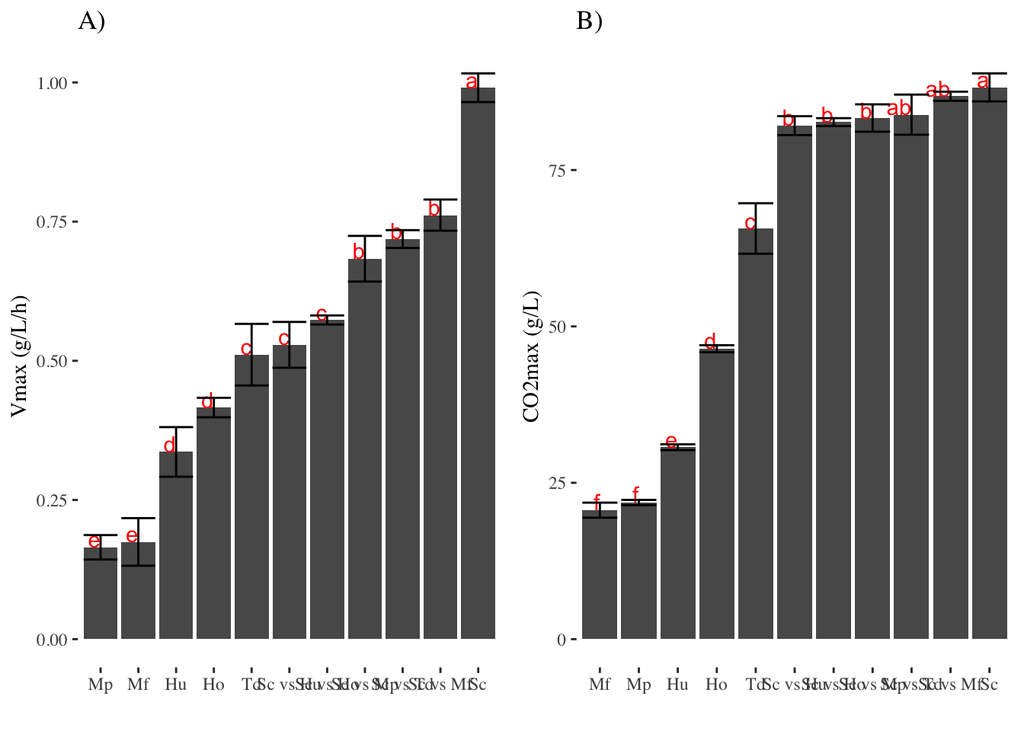

```r
grid.arrange(g.Vmax,g.MaxCO2,ncol = 2)
```

# Population

```r
stock.para.pop <- NULL
par(mfrow = c(3,3))
myerror <- NULL
for(k in unique(mypopulation$Blocs)){
    sub.data.1 <- mypopulation %>% filter(Blocs == k)
    for(i in unique(sub.data.1$Species)){
        sub.data.2 <- sub.data.1 %>% filter(Species == i)
        for(j in unique(sub.data.2$Fermenter)){
            sub.data <- sub.data.2 %>% filter(Fermenter == j)


            mypropfinal <- last(sub.data$Prop_Sc)
            myviability <- last(sub.data$viability)

            myfit <- gcFitModel(sub.data$Time, sub.data$Pop_total,control = grofit.control(suppress.messages = T))

            mymu <- myfit$parameters$mu[1]
            myK = myfit$parameters$A[1]
            mylatency = myfit$parameters$lambda[1]

            # plot(myfit$raw.time,myfit$raw.data,main=paste(k,i,j,sep="/"))
            # if(length(myfit$fit.data) > 1){
            #     lines(myfit$fit.time,myfit$fit.data,col=2)
            # }else{
            #     myerror <- rbind(myerror, c(i,j,k))
            # }





            stock.para.pop <- rbind.data.frame(stock.para.pop,
                                          data.frame(Bloc = k,
                                                     Species = i,
                                                     Fermenter = j,
                                                     mu = mymu,
                                                     K = myK,
                                                     latency = mylatency,
                                                     propfinal = mypropfinal,
                                                     viability = myviability))
        }

    }
}
```

## mu

```r
mu.aov <- aov(mu~Species,data = stock.para.pop)
mu.tukey <- HSD.test(mu.aov,"Species")

anova(lm(mu~Species+Bloc,stock.para.pop))
```

```
## Analysis of Variance Table
##
## Response: mu
##           Df     Sum Sq    Mean Sq F value    Pr(>F)
## Species   10 3.3523e+14 3.3523e+13 29.6294 1.807e-10 ***
## Bloc       4 4.6138e+12 1.1534e+12  1.0195     0.419
## Residuals 22 2.4891e+13 1.1314e+12
## ---
## Signif. codes:  0 '***' 0.001 '**' 0.01 '*' 0.05 '.' 0.1 ' ' 1
```

```r
means.mu <- mu.tukey$means %>%
    select(mu,std) %>%
    mutate(ymin = mu - std, ymax = mu + std)
means.mu$Species <- row.names(mu.tukey$means)
groups.mu <- mu.tukey$groups
groups.mu$Species <- rownames(groups.mu)

means.mu <- left_join(means.mu,groups.mu, by = "Species") %>%
    select(Species,mu = mu.x, std, ymin, ymax, groups)

means.mu <- means.mu %>%
    mutate(mu.red = mu/1000000,std.red = std/1000000)

knitr::kable(means.mu, digits = 2)
```

| Species | mu | std | ymin | ymax | groups | mu.red | std.red |
| --- | --- | --- | --- | --- | --- | --- | --- |
| Ho | 7752422 | 2324482.5 | 5427940 | 10076905 | bc | 7.75 | 2.32 |
| Hu | 15590060 | 2957827.7 | 12632232 | 18547887 | a | 15.59 | 2.96 |
| Mf | 3383545 | 764180.2 | 2619365 | 4147725 | de | 3.38 | 0.76 |
| Mp | 2382139 | 400582.4 | 1981557 | 2782722 | e | 2.38 | 0.40 |
| Sc | 5614507 | 816368.8 | 4798139 | 6430876 | cd | 5.61 | 0.82 |
| Sc vs Ho | 5689865 | 304279.4 | 5385586 | 5994145 | bcd | 5.69 | 0.30 |
| Sc vs Hu | 8668339 | 606340.3 | 8061999 | 9274679 | b | 8.67 | 0.61 |
| Sc vs Mf | 3120098 | 237008.0 | 2883090 | 3357106 | de | 3.12 | 0.24 |
| Sc vs Mp | 2837393 | 59837.3 | 2777556 | 2897231 | de | 2.84 | 0.06 |
| Sc vs Td | 4173408 | 566514.2 | 3606894 | 4739923 | de | 4.17 | 0.57 |
| Td | 5318659 | 1027979.6 | 4290680 | 6346639 | cde | 5.32 | 1.03 |

```r
g.mu <- means.mu %>%
    ggplot(aes(x = reorder(Species,mu), y = mu, ymin = ymin, ymax = ymax, label = groups)) +
    geom_bar(stat = "identity") +
    geom_text(col = "red",vjust = 0, hjust = 1) +
    geom_errorbar() +
    theme_tufte() +
    labs(x = "", y = "mu (cells/mL/h)",title = "A)")
```

## K

```r
K.aov <- aov(K~Species,data = stock.para.pop)
K.tukey <- HSD.test(K.aov,"Species")

anova(lm(K~Species+Bloc,stock.para.pop))
```

```
## Analysis of Variance Table
##
## Response: K
##           Df     Sum Sq    Mean Sq F value    Pr(>F)
## Species   10 6.1403e+16 6.1403e+15 243.473 < 2.2e-16 ***
## Bloc       4 1.6704e+15 4.1760e+14  16.558 2.144e-06 ***
## Residuals 22 5.5484e+14 2.5220e+13
## ---
## Signif. codes:  0 '***' 0.001 '**' 0.01 '*' 0.05 '.' 0.1 ' ' 1
```

```r
means.K <- K.tukey$means %>%
    select(K,std) %>%
    mutate(ymin = K - std, ymax = K + std)
means.K$Species <- row.names(K.tukey$means)
groups.K <- K.tukey$groups
groups.K$Species <- rownames(groups.K)

means.K <- left_join(means.K,groups.K, by = "Species") %>%
    select(Species,K = K.x, std, ymin, ymax, groups)

means.K <- means.K %>%
    mutate(K.red = K/100000000,std.red = std/100000000)

knitr::kable(means.K, digits = 2)
```

| Species | K | std | ymin | ymax | groups | K.red | std.red |
| --- | --- | --- | --- | --- | --- | --- | --- |
| Ho | 162685462 | 7001531 | 155683931 | 169686993 | bc | 1.63 | 0.07 |
| Hu | 139183774 | 8674840 | 130508934 | 147858614 | cd | 1.39 | 0.09 |
| Mf | 81602458 | 4792874 | 76809585 | 86395332 | e | 0.82 | 0.05 |
| Mp | 58476291 | 1136424 | 57339867 | 59612715 | e | 0.58 | 0.01 |
| Sc | 156092588 | 15798906 | 140293682 | 171891494 | bc | 1.56 | 0.16 |
| Sc vs Ho | 228059806 | 7954474 | 220105333 | 236014280 | a | 2.28 | 0.08 |
| Sc vs Hu | 172509917 | 5530739 | 166979178 | 178040656 | b | 1.73 | 0.06 |
| Sc vs Mf | 133730136 | 3222234 | 130507903 | 136952370 | d | 1.34 | 0.03 |
| Sc vs Mp | 133256059 | 1259167 | 131996892 | 134515226 | d | 1.33 | 0.01 |
| Sc vs Td | 149689036 | 1133092 | 148555944 | 150822128 | bcd | 1.50 | 0.01 |
| Td | 123561460 | 4579113 | 118982347 | 128140573 | d | 1.24 | 0.05 |

```r
g.K <- means.K %>%
    ggplot(aes(x = reorder(Species,K), y = K, ymin = ymin, ymax = ymax, label = groups)) +
    geom_bar(stat = "identity") +
    geom_text(col = "red",vjust = 0, hjust = 1) +
    geom_errorbar() +
    theme_tufte() +
    labs(x = "", y = "K (cells/mL)",title = "B)")
```

## Prop

```r
propfinal.aov <- aov(propfinal~Species,data = stock.para.pop %>% filter(grepl("vs",Species)))
propfinal.tukey <- HSD.test(propfinal.aov,"Species")

anova(lm(propfinal~Species,stock.para.pop%>% filter(grepl("vs",Species))))
```

```
## Analysis of Variance Table
##
## Response: propfinal
##           Df  Sum Sq Mean Sq F value    Pr(>F)
## Species    4 0.81177 0.20294   724.8 2.871e-12 ***
## Residuals 10 0.00280 0.00028
## ---
## Signif. codes:  0 '***' 0.001 '**' 0.01 '*' 0.05 '.' 0.1 ' ' 1
```

```r
means.propfinal <- propfinal.tukey$means %>%
    select(propfinal,std) %>%
    mutate(ymin = propfinal - std, ymax = propfinal + std)
means.propfinal$Species <- row.names(propfinal.tukey$means)
groups.propfinal <- propfinal.tukey$groups
groups.propfinal$Species <- rownames(groups.propfinal)

means.propfinal <- left_join(means.propfinal,groups.propfinal, by = "Species") %>%
    select(Species,propfinal = propfinal.x, std, ymin, ymax, groups)


knitr::kable(means.propfinal, digits = 2)
```

| Species | propfinal | std | ymin | ymax | groups |
| --- | --- | --- | --- | --- | --- |
| Sc vs Ho | 0.83 | 0.02 | 0.81 | 0.84 | b |
| Sc vs Hu | 0.76 | 0.01 | 0.76 | 0.77 | c |
| Sc vs Mf | 0.96 | 0.02 | 0.94 | 0.98 | a |
| Sc vs Mp | 0.50 | 0.02 | 0.48 | 0.52 | d |
| Sc vs Td | 0.32 | 0.02 | 0.30 | 0.34 | e |

```r
g.propfinal <- means.propfinal %>%
    ggplot(aes(x = reorder(Species,propfinal), y = propfinal, ymin = ymin, ymax = ymax, label = groups)) +
    geom_bar(stat = "identity") +
    geom_text(col = "red",vjust = 0, hjust = 1) +
    geom_errorbar() +
    theme_tufte() +
    labs(x = "", y = "Sc final proportion",title = "C)")
```

## Viability

```r
viability.aov <- aov(viability~Species,data = stock.para.pop)
viability.tukey <- HSD.test(viability.aov,"Species")

anova(lm(viability~Species+Bloc,stock.para.pop))
```

```
## Analysis of Variance Table
##
## Response: viability
##           Df  Sum Sq  Mean Sq F value    Pr(>F)
## Species   10 2.42994 0.242994 229.837 < 2.2e-16 ***
## Bloc       4 0.04590 0.011475  10.854 4.307e-05 ***
## Residuals 23 0.02432 0.001057
## ---
## Signif. codes:  0 '***' 0.001 '**' 0.01 '*' 0.05 '.' 0.1 ' ' 1
```

```r
means.viability <- viability.tukey$means %>%
    select(viability,std) %>%
    mutate(ymin = viability - std, ymax = viability + std)
means.viability$Species <- row.names(viability.tukey$means)
groups.viability <- viability.tukey$groups
groups.viability$Species <- rownames(groups.viability)

means.viability <- left_join(means.viability,groups.viability, by = "Species") %>%
    select(Species,viability = viability.x, std, ymin, ymax, groups)


knitr::kable(means.viability, digits = 2)
```

| Species | viability | std | ymin | ymax | groups |
| --- | --- | --- | --- | --- | --- |
| Ho | 0.24 | 0.02 | 0.22 | 0.25 | h |
| Hu | 0.29 | 0.04 | 0.25 | 0.32 | gh |
| Mf | 0.96 | 0.01 | 0.95 | 0.96 | ab |
| Mp | 0.92 | 0.02 | 0.91 | 0.94 | ab |
| Sc | 0.84 | 0.09 | 0.75 | 0.93 | bc |
| Sc vs Ho | 0.39 | 0.02 | 0.37 | 0.41 | fg |
| Sc vs Hu | 0.54 | 0.04 | 0.50 | 0.57 | ef |
| Sc vs Mf | 0.75 | 0.04 | 0.71 | 0.78 | cd |
| Sc vs Mp | 0.63 | 0.05 | 0.58 | 0.68 | de |
| Sc vs Td | 0.94 | 0.01 | 0.93 | 0.95 | ab |
| Td | 0.97 | 0.02 | 0.95 | 0.99 | a |

```r
g.viability <- means.viability %>%
    ggplot(aes(x = reorder(Species,viability), y = viability, ymin = ymin, ymax = ymax, label = groups)) +
    geom_bar(stat = "identity") +
    geom_text(col = "red",vjust = 0, hjust = 1) +
    geom_errorbar() +
    theme_tufte() +
    labs(x = "", y = "Final viability",title = "D)")
```

## Graphics

### Parameters

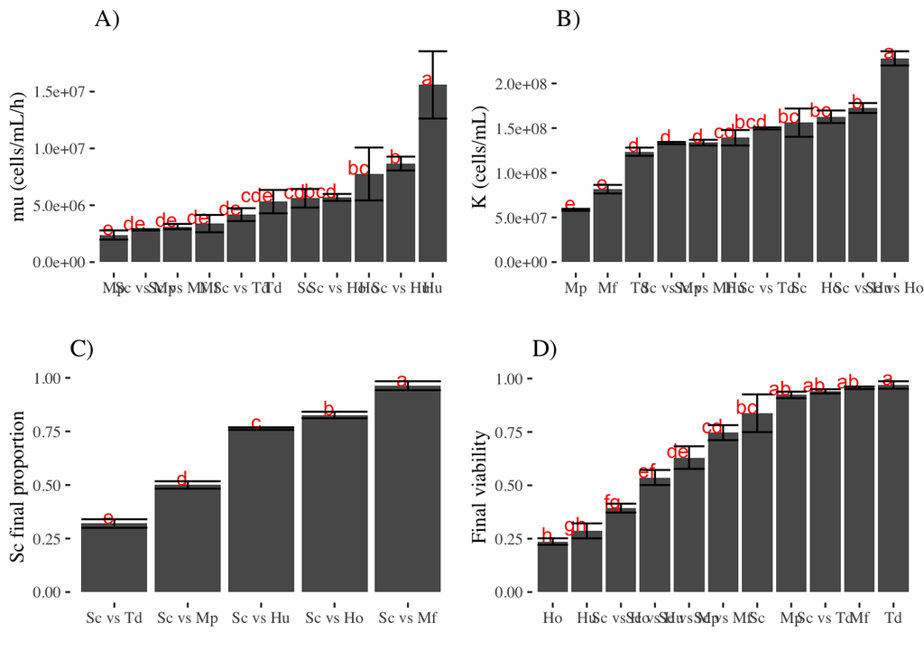

```r
grid.arrange(g.mu,g.K,g.propfinal,g.viability,ncol = 2)
```

### Dynamcis

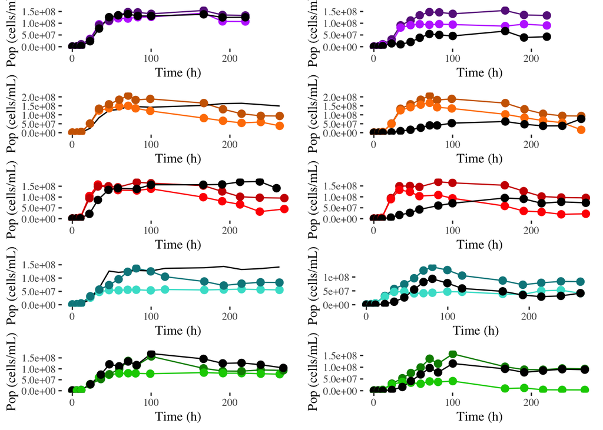

```r
g.popvivante.td <- mypopulation %>%
    filter(Blocs == "Sc vs Td") %>%
    select(Species, Time,PopV) %>%
    group_by(Time,Species) %>%
    dplyr::summarise(sdt = erreur.std(PopV),
              PopV = mean(PopV)) %>%
    mutate(ymin = PopV - sdt, ymax = PopV + sdt) %>%
    ungroup() %>%
    ggplot(aes(x = Time, y = PopV, color = Species, ymax = ymax, ymin = ymin)) +
    geom_line() +
    geom_pointrange() +
    scale_y_continuous(limits=c(1,max(mypopulation$PopV)))+
    scale_x_continuous(limits=c(0,max(mypopulation$Time)))+
    scale_shape_manual(values=c(19,19,20))+
    scale_color_manual(values = c("darkorchid1","darkorchid4","black")) +
    scale_linetype_manual( values = c(1,3,1)) +
    theme_tufte()+
    theme(legend.position ="None") +
    labs(x = "Time (h)", y = "Pop (cells/mL)")

g.souspop.td <- mypopulation %>%
    filter(Species == "Sc vs Td") %>%
    select(Time,PopV,PopV.Sacc,PopV.NonSacc) %>%
    gather(key = type, val = pop,-Time) %>%
    group_by(Time,type) %>%
    dplyr::summarise(sdt = erreur.std(pop),
              pop = mean(pop)) %>%
    mutate(ymin = pop - sdt, ymax = pop + sdt) %>%
    ungroup() %>%
    ggplot(aes(x = Time, y = pop, color = type, ymax = ymax, ymin = ymin)) +
    geom_line() +
    geom_pointrange() +
    scale_y_continuous(limits=c(1,max(mypopulation$PopV)))+
    scale_x_continuous(limits=c(0,max(mypopulation$Time)))+
    scale_shape_manual(values=c(19,19,20))+
    scale_color_manual(values = c("darkorchid4","darkorchid1","black")) +
    scale_linetype_manual(values = c(1,2,2)) +
    theme_tufte()+
    theme(legend.position ="None") +
    labs(x = "Time (h)", y = "Pop (cells/mL)")


g.popvivante.ho <- mypopulation %>%
    filter(Blocs == "Sc vs Ho") %>%
    select(Species, Time,PopV) %>%
    group_by(Time,Species) %>%
    dplyr::summarise(sdt = erreur.std(PopV),
              PopV = mean(PopV)) %>%
    mutate(ymin = PopV - sdt, ymax = PopV + sdt) %>%
    ungroup() %>%
    ggplot(aes(x = Time, y = PopV, color = Species, ymax = ymax, ymin = ymin)) +
    geom_line() +
    geom_pointrange() +
    scale_y_continuous(limits=c(1,max(mypopulation$PopV)))+
    scale_x_continuous(limits=c(0,max(mypopulation$Time)))+
    scale_shape_manual(values=c(19,19,20))+
    scale_color_manual(values = c("darkorange1", "darkorange3","black")) +
    scale_linetype_manual( values = c(1,3,1)) +
    theme_tufte()+
    theme(legend.position ="None") +
    labs(x = "Time (h)", y = "Pop (cells/mL)")

g.souspop.ho <- mypopulation %>%
    filter(Species == "Sc vs Ho") %>%
    select(Time,PopV,PopV.Sacc,PopV.NonSacc) %>%
    gather(key = type, val = pop,-Time) %>%
    group_by(Time,type) %>%
    dplyr::summarise(sdt = erreur.std(pop),
              pop = mean(pop)) %>%
    mutate(ymin = pop - sdt, ymax = pop + sdt) %>%
    ungroup() %>%
    ggplot(aes(x = Time, y = pop, color = type, ymax = ymax, ymin = ymin)) +
    geom_line() +
    geom_pointrange() +
    scale_y_continuous(limits=c(1,max(mypopulation$PopV)))+
    scale_x_continuous(limits=c(0,max(mypopulation$Time)))+
    scale_shape_manual(values=c(19,19,20))+
    scale_color_manual(values = c("darkorange3","darkorange1","black")) +
    scale_linetype_manual(values = c(1,2,2)) +
    theme_tufte()+
    theme(legend.position ="None") +
    labs(x = "Time (h)", y = "Pop (cells/mL)")

g.popvivante.hu <- mypopulation %>%
    filter(Blocs == "Sc vs Hu") %>%
    select(Species, Time,PopV) %>%
    group_by(Time,Species) %>%
    dplyr::summarise(sdt = erreur.std(PopV),
              PopV = mean(PopV)) %>%
    mutate(ymin = PopV - sdt, ymax = PopV + sdt) %>%
    ungroup() %>%
    ggplot(aes(x = Time, y = PopV, color = Species, ymax = ymax, ymin = ymin)) +
    geom_line() +
    geom_pointrange() +
    scale_y_continuous(limits=c(1,max(mypopulation$PopV)))+
    scale_x_continuous(limits=c(0,max(mypopulation$Time)))+
    scale_shape_manual(values=c(19,19,20))+
    scale_color_manual(values = c("red", "red3", "black")) +
    scale_linetype_manual( values = c(1,3,1)) +
    theme_tufte()+
    theme(legend.position ="None") +
    labs(x = "Time (h)", y = "Pop (cells/mL)")

g.souspop.hu <- mypopulation %>%
    filter(Species == "Sc vs Hu") %>%
    select(Time,PopV,PopV.Sacc,PopV.NonSacc) %>%
    gather(key = type, val = pop,-Time) %>%
    group_by(Time,type) %>%
    dplyr::summarise(sdt = erreur.std(pop),
              pop = mean(pop)) %>%
    mutate(ymin = pop - sdt, ymax = pop + sdt) %>%
    ungroup() %>%
    ggplot(aes(x = Time, y = pop, color = type, ymax = ymax, ymin = ymin)) +
    geom_line() +
    geom_pointrange() +
    scale_y_continuous(limits=c(1,max(mypopulation$PopV)))+
    scale_x_continuous(limits=c(0,max(mypopulation$Time)))+
    scale_shape_manual(values=c(19,19,20))+
    scale_color_manual(values = c("red3","red","black")) +
    scale_linetype_manual(values = c(1,2,2)) +
    theme_tufte()+
    theme(legend.position ="None") +
    labs(x = "Time (h)", y = "Pop (cells/mL)")

g.popvivante.mp <- mypopulation %>%
    filter(Blocs == "Sc vs Mp") %>%
    select(Species, Time,PopV) %>%
    group_by(Time,Species) %>%
    dplyr::summarise(sdt = erreur.std(PopV),
              PopV = mean(PopV)) %>%
    mutate(ymin = PopV - sdt, ymax = PopV + sdt) %>%
    ungroup() %>%
    ggplot(aes(x = Time, y = PopV, color = Species, ymax = ymax, ymin = ymin)) +
    geom_line() +
    geom_pointrange() +
    scale_y_continuous(limits=c(1,max(mypopulation$PopV)))+
    scale_x_continuous(limits=c(0,max(mypopulation$Time)))+
    scale_shape_manual(values=c(19,19,20))+
    scale_color_manual(values = c("turquoise","turquoise4","black")) +
    scale_linetype_manual( values = c(1,3,1)) +
    theme_tufte()+
    theme(legend.position ="None") +
    labs(x = "Time (h)", y = "Pop (cells/mL)")

g.souspop.mp <- mypopulation %>%
    filter(Species == "Sc vs Mp") %>%
    select(Time,PopV,PopV.Sacc,PopV.NonSacc) %>%
    gather(key = type, val = pop,-Time) %>%
    group_by(Time,type) %>%
    dplyr::summarise(sdt = erreur.std(pop),
              pop = mean(pop)) %>%
    mutate(ymin = pop - sdt, ymax = pop + sdt) %>%
    ungroup() %>%
    ggplot(aes(x = Time, y = pop, color = type, ymax = ymax, ymin = ymin)) +
    geom_line() +
    geom_pointrange() +
    scale_y_continuous(limits=c(1,max(mypopulation$PopV)))+
    scale_x_continuous(limits=c(0,max(mypopulation$Time)))+
    scale_shape_manual(values=c(19,19,20))+
    scale_color_manual(values = c("turquoise4","turquoise","black")) +
    scale_linetype_manual(values = c(1,2,2)) +
    theme_tufte()+
    theme(legend.position ="None") +
    labs(x = "Time (h)", y = "Pop (cells/mL)")


g.popvivante.mf <- mypopulation %>%
    filter(Blocs == "Sc vs Mf") %>%
    select(Species, Time,PopV) %>%
    group_by(Time,Species) %>%
    dplyr::summarise(sdt = erreur.std(PopV),
              PopV = mean(PopV)) %>%
    mutate(ymin = PopV - sdt, ymax = PopV + sdt) %>%
    ungroup() %>%
    ggplot(aes(x = Time, y = PopV, color = Species, ymax = ymax, ymin = ymin)) +
    geom_line() +
    geom_pointrange() +
    scale_y_continuous(limits=c(1,max(mypopulation$PopV)))+
    scale_x_continuous(limits=c(0,max(mypopulation$Time)))+
    scale_shape_manual(values=c(19,19,20))+
    scale_color_manual(values = c("green3","green4","black")) +
    scale_linetype_manual( values = c(1,3,1)) +
    theme_tufte()+
    theme(legend.position ="None") +
    labs(x = "Time (h)", y = "Pop (cells/mL)")

g.souspop.mf <- mypopulation %>%
    filter(Species == "Sc vs Mf") %>%
    select(Time,PopV,PopV.Sacc,PopV.NonSacc) %>%
    gather(key = type, val = pop,-Time) %>%
    group_by(Time,type) %>%
    dplyr::summarise(sdt = erreur.std(pop),
              pop = mean(pop)) %>%
    mutate(ymin = pop - sdt, ymax = pop + sdt) %>%
    ungroup() %>%
    ggplot(aes(x = Time, y = pop, color = type, ymax = ymax, ymin = ymin)) +
    geom_line() +
    geom_pointrange() +
    scale_y_continuous(limits=c(1,max(mypopulation$PopV)))+
    scale_x_continuous(limits=c(0,max(mypopulation$Time)))+
    scale_shape_manual(values=c(19,19,20))+
    scale_color_manual(values = c("green4","green3","black")) +
    scale_linetype_manual(values = c(1,2,2)) +
    theme_tufte()+
    theme(legend.position ="None") +
    labs(x = "Time (h)", y = "Pop (cells/mL)")

g.population <- grid.arrange(g.popvivante.td,g.souspop.td,
             g.popvivante.ho,g.souspop.ho,
             g.popvivante.hu,g.souspop.hu,
             g.popvivante.mp,g.souspop.mp,
             g.popvivante.mf,g.souspop.mf,
             ncol=2)
```

```r
ggsave(g.population,file="population.png")
```

# Resources consumption

## Sugar

```r
mydata.sugar <- NULL
for(i in unique(mydata.hplc$Blocs)){
    sub.data.1 <- mydata.hplc %>% filter(Blocs == i)
    for(j in unique(sub.data.1$Fermenter)){
        sub.data <- sub.data.1 %>%
            filter(Fermenter == j) %>%
            filter(Time == max(Time))

        mydata.sugar <- rbind.data.frame(mydata.sugar, data.frame(Blocs = i,Fermenter = j, Species = sub.data$Species,glucose = sub.data$glucose, fructose = sub.data$fructose))
    }
}

mydata.sugar$sugar <- mydata.sugar$glucose + mydata.sugar$fructose

sugar.aov <- aov(sugar~Species,data = mydata.sugar)
sugar.tukey <- HSD.test(sugar.aov,"Species")

anova(lm(sugar~Species+Blocs,mydata.sugar))
```

```
## Analysis of Variance Table
##
## Response: sugar
##           Df Sum Sq Mean Sq  F value Pr(>F)
## Species   10 100624 10062.4 256.3605 <2e-16 ***
## Blocs      4      0     0.1   0.0013      1
## Residuals 22    864    39.3
## ---
## Signif. codes:  0 '***' 0.001 '**' 0.01 '*' 0.05 '.' 0.1 ' ' 1
```

```r
means.sugar <- sugar.tukey$means %>%
    select(sugar,std) %>%
    mutate(ymin = sugar - std, ymax = sugar + std)
means.sugar$Species <- row.names(sugar.tukey$means)
groups.sugar <- sugar.tukey$groups
groups.sugar$Species <- rownames(groups.sugar)

means.sugar <- left_join(means.sugar,groups.sugar, by = "Species") %>%
    select(Species,sugar = sugar.x, std, ymin, ymax, groups)
means.sugar$Species <- factor(means.sugar$Species, levels = c( "Ho","Sc vs Ho", "Hu","Sc vs Hu", "Mf", "Sc vs Mf","Mp","Sc vs Mp","Td","Sc vs Td",  "Sc"))


knitr::kable(means.sugar, digits = 2)
```

| Species | sugar | std | ymin | ymax | groups |
| --- | --- | --- | --- | --- | --- |
| Ho | 92.30 | 1.40 | 90.90 | 93.70 | b |
| Hu | 134.35 | 11.19 | 123.16 | 145.53 | a |
| Mf | 135.85 | 9.68 | 126.18 | 145.53 | a |
| Mp | 142.00 | 3.75 | 138.25 | 145.74 | a |
| Sc | 0.24 | 0.19 | 0.05 | 0.43 | f |
| Sc vs Ho | 23.35 | 1.29 | 22.06 | 24.64 | de |
| Sc vs Hu | 16.53 | 6.46 | 10.07 | 22.99 | e |
| Sc vs Mf | 9.93 | 2.06 | 7.86 | 11.99 | ef |
| Sc vs Mp | 20.81 | 6.05 | 14.75 | 26.86 | de |
| Sc vs Td | 35.85 | 5.25 | 30.60 | 41.11 | d |
| Td | 63.53 | 11.49 | 52.05 | 75.02 | c |

```r
g.sugar <- means.sugar %>%
    ggplot(aes(x = Species, y = sugar, ymin = ymin, ymax = ymax, label = groups,fill = Species)) +
    geom_bar(stat = "identity") +
    geom_text(col = "red",vjust = 0, hjust = 1) +
    geom_errorbar() +
    scale_fill_manual(values = c("darkorange","darkorange3","red","red3","green3","green4","turquoise","turquoise3","darkorchid1","darkorchid4","black")) +
    theme_tufte() +
    labs(x = "", y = "Concentration (g/L)") +
    theme(axis.text.x = element_text(angle = 90, hjust = 1, vjust = 0.5), legend.position='none')
```

## Total NAS

```r
mydata.aa$total <- apply(mydata.aa[,c("Ammonium","Alanine","Arginine","Aspartate","Glutamine","Glutamate","Glycine","Histidine","Methionine","Phenylalanine","Serine","Threonine","Tryptophane","Tyrosine","Valine")],1,sum)

stock.cons.aa <- NULL
for(i in unique(mydata.aa$Blocs)){
    sub.data.1 <- mydata.aa %>% filter(Blocs == i)
    for(j in unique(sub.data.1$Fermenter)){
        sub.data.2 <- sub.data.1 %>% filter(Fermenter == j)
        for(k in 5:ncol(sub.data.2)){
            sub.data <- data.frame(sub.data.2$Time,sub.data.2[,k])

            delta.aa <- as.numeric(sub.data.2[1,k] - sub.data.2[2,k])
            ratio.aa <- as.numeric(delta.aa/sub.data.2[1,k])

            stock.cons.aa <- rbind.data.frame(stock.cons.aa,
                                              data.frame(Blocs = i,
                                                         Species = sub.data.2$Species[1],
                                                         AA = colnames(sub.data.2)[k],
                                                         debut = as.numeric(sub.data.2[1,k]),
                                                         fin = as.numeric(sub.data.2[2,k]),
                                                         delta = delta.aa,
                                                         ratio = ratio.aa))
        }
    }
}


left.NAS.aov <- aov(fin~Species,data = stock.cons.aa %>% filter(AA == "total"))
left.NAS.tukey <- HSD.test(left.NAS.aov,"Species")

anova(lm(fin~Species+Blocs,stock.cons.aa %>% filter(AA == "total")))
```

```
## Analysis of Variance Table
##
## Response: fin
##           Df Sum Sq Mean Sq F value    Pr(>F)
## Species   10 401466   40147 97.3269 7.743e-16 ***
## Blocs      4   1781     445  1.0795    0.3906
## Residuals 22   9075     412
## ---
## Signif. codes:  0 '***' 0.001 '**' 0.01 '*' 0.05 '.' 0.1 ' ' 1
```

```r
means.left.NAS <- left.NAS.tukey$means %>%
    select(fin,std) %>%
    mutate(ymin = fin - std, ymax = fin + std)
means.left.NAS$Species <- row.names(left.NAS.tukey$means)
groups.left.NAS <- left.NAS.tukey$groups
groups.left.NAS$Species <- rownames(groups.left.NAS)

means.left.NAS <- left_join(means.left.NAS,groups.left.NAS, by = "Species") %>%
    select(Species,NAS = fin.x, std, ymin, ymax, groups)
means.left.NAS$Species <- factor(means.left.NAS$Species, levels = c( "Ho","Sc vs Ho", "Hu","Sc vs Hu", "Mf", "Sc vs Mf","Mp","Sc vs Mp","Td","Sc vs Td",  "Sc"))


knitr::kable(means.left.NAS, digits = 2)
```

| Species | NAS | std | ymin | ymax | groups |
| --- | --- | --- | --- | --- | --- |
| Ho | 122.19 | 6.06 | 116.13 | 128.25 | bc |
| Hu | 173.32 | 42.93 | 130.39 | 216.25 | b |
| Mf | 256.66 | 5.05 | 251.61 | 261.70 | a |
| Mp | 305.52 | 10.30 | 295.22 | 315.82 | a |
| Sc | 10.43 | 24.22 | -13.79 | 34.65 | d |
| Sc vs Ho | 6.42 | 2.42 | 3.99 | 8.84 | d |
| Sc vs Hu | 4.63 | 4.20 | 0.43 | 8.83 | d |
| Sc vs Mf | 1.80 | 0.16 | 1.64 | 1.97 | d |
| Sc vs Mp | 2.07 | 0.27 | 1.80 | 2.35 | d |
| Sc vs Td | 1.78 | 0.20 | 1.58 | 1.98 | d |
| Td | 112.56 | 36.62 | 75.94 | 149.17 | c |

```r
g.NAS <- means.left.NAS %>%
    ggplot(aes(x = Species, y = NAS, ymin = ymin, ymax = ymax, label = groups,fill = Species)) +
    geom_bar(stat = "identity") +
    geom_text(col = "red",vjust = 0, hjust = 1) +
    geom_errorbar() +
    scale_fill_manual(values = c("darkorange","darkorange3","red","red3","green3","green4","turquoise","turquoise3","darkorchid1","darkorchid4","black")) +
    theme_tufte() +
    labs(x = "", y = "Concentration (mg/L)") +
    theme(axis.text.x = element_text(angle = 90, hjust = 1, vjust = 0.5), legend.position='none')
```

## Ratio by AA

```r
AA.ratio <- stock.cons.aa %>%
    group_by(Species,AA) %>%
    dplyr::summarise(mean = mean(ratio))

myorder.AA <- AA.ratio %>%
    group_by(AA) %>%
    dplyr::summarise(mean = mean(mean)) %>%
    arrange(mean) %>%
    select(AA) %>%
    as.data.frame()
myorder.AA <- as.character(myorder.AA[,1])

myorder.Species <- AA.ratio %>%
    group_by(Species) %>%
    dplyr::summarise(mean = mean(mean)) %>%
    arrange(mean) %>%
    select(Species) %>%
    as.data.frame()
myorder.Species <- as.character(myorder.Species[,1])

AA.ratio$AA <- factor(AA.ratio$AA, levels = myorder.AA)
AA.ratio$Species <- factor(AA.ratio$Species, levels = myorder.Species)

g.aa.ratio <- AA.ratio %>%
    filter(AA != "total") %>%
    ggplot(aes(x = Species,y = AA)) +
    geom_tile(aes(fill = mean)) +
    scale_fill_gradient2(low = "darkgreen",high = "red",na.value = "grey50",midpoint = 0.75) +
    theme_tufte() +
    labs(x="Species",y="Amino Acids",title="Consumption ratio of Nitrogen sources by Species") +
    geom_text(aes(x=Species,y=AA,label=paste(round(mean*100),"%",sep="")),size = 3) +
    theme(axis.text.x = element_text(angle = 90, hjust = 1, vjust = 0.5))
```

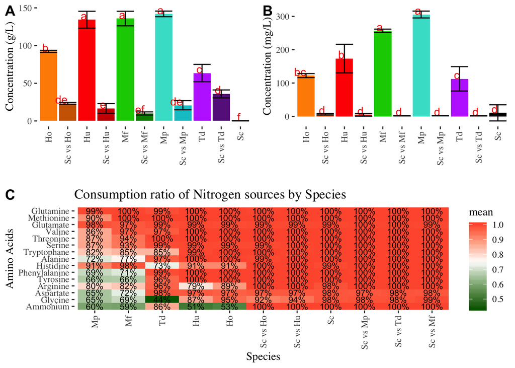

```r
figure3 <- ggarrange(ggarrange(g.sugar, g.NAS, ncol = 2, labels = c("A", "B")),
          g.aa.ratio,nrow = 2, labels = c("","C"))

figure3
```

# Production total HPLC

```
## [1] "############  glycerol  ############"
## Analysis of Variance Table
##
## Response: metabolite
##           Df Sum Sq Mean Sq F value    Pr(>F)
## Species   10 35.038  3.5038 99.2464 6.285e-16 ***
## Blocs      4  1.306  0.3265  9.2489 0.0001532 ***
## Residuals 22  0.777  0.0353
## ---
## Signif. codes:  0 '***' 0.001 '**' 0.01 '*' 0.05 '.' 0.1 ' ' 1
##
##
## Species     metabolite    std   ymin   ymax  groups
## ---------  -----------  -----  -----  -----  -------
## Ho                5.21   0.04   5.17   5.24  c
## Hu                5.55   0.22   5.33   5.77  bc
## Mf                2.76   0.11   2.66   2.87  e
## Mp                3.73   0.20   3.52   3.93  d
## Sc                5.34   0.44   4.91   5.78  c
## Sc vs Ho          6.01   0.03   5.97   6.04  abc
## Sc vs Hu          6.56   0.34   6.22   6.90  a
## Sc vs Mf          5.96   0.12   5.84   6.08  abc
## Sc vs Mp          6.10   0.12   5.98   6.22  ab
## Sc vs Td          5.21   0.24   4.97   5.45  c
## Td                3.98   0.28   3.70   4.26  d
```

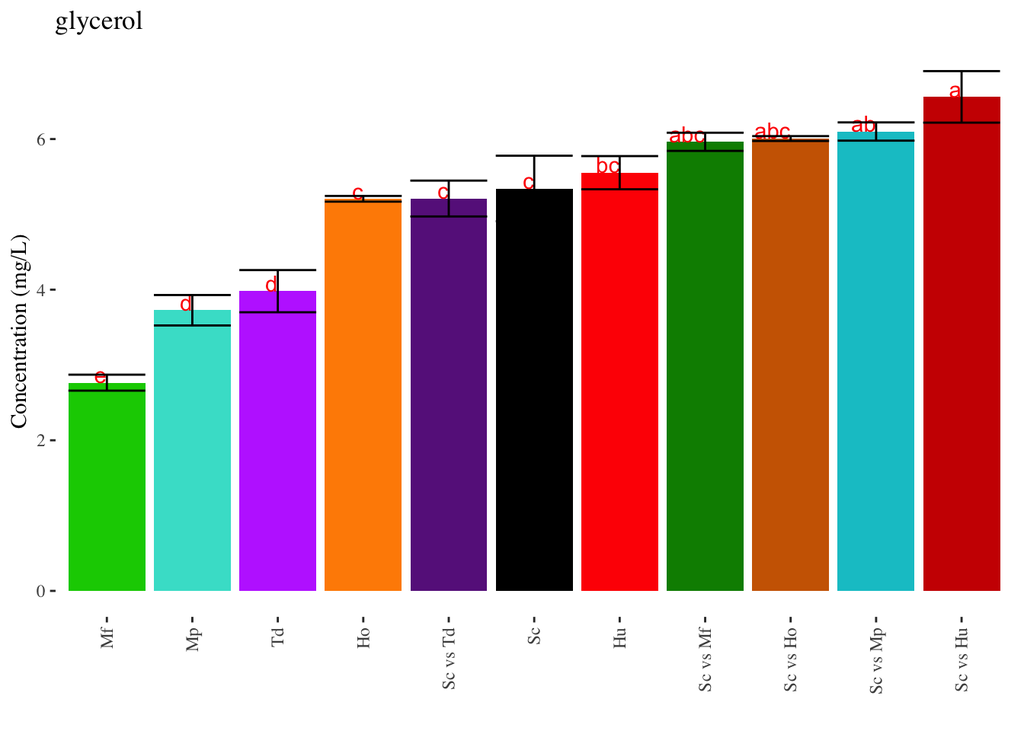

```
## [1] "############  acetate  ############"
## Analysis of Variance Table
##
## Response: metabolite
##           Df Sum Sq Mean Sq  F value  Pr(>F)
## Species   10 3.9875 0.39875 239.6869 < 2e-16 ***
## Blocs      4 0.0182 0.00456   2.7406 0.05453 .
## Residuals 22 0.0366 0.00166
## ---
## Signif. codes:  0 '***' 0.001 '**' 0.01 '*' 0.05 '.' 0.1 ' ' 1
##
##
## Species     metabolite    std   ymin   ymax  groups
## ---------  -----------  -----  -----  -----  -------
## Ho                0.99   0.02   0.97   1.01  b
## Hu                1.15   0.03   1.12   1.18  a
## Mf                0.12   0.01   0.12   0.13  g
## Mp                0.07   0.06   0.01   0.12  g
## Sc                0.63   0.06   0.57   0.70  d
## Sc vs Ho          0.84   0.01   0.83   0.84  c
## Sc vs Hu          0.86   0.07   0.79   0.93  bc
## Sc vs Mf          0.46   0.02   0.44   0.48  e
## Sc vs Mp          0.46   0.02   0.44   0.49  e
## Sc vs Td          0.27   0.06   0.22   0.33  f
## Td                0.17   0.03   0.15   0.20  fg
```

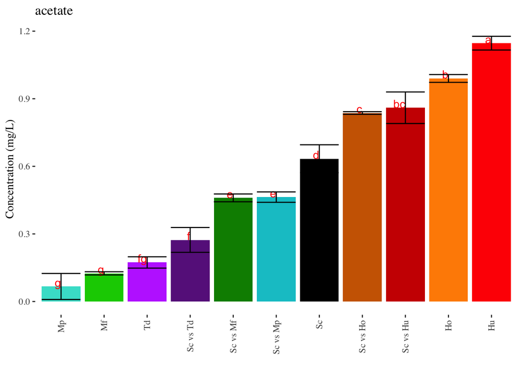

```
## [1] "############  ethanol  ############"
## Analysis of Variance Table
##
## Response: metabolite
##           Df  Sum Sq Mean Sq F value    Pr(>F)
## Species   10 26410.3 2641.03 283.740 < 2.2e-16 ***
## Blocs      4   461.4  115.35  12.392 1.996e-05 ***
## Residuals 22   204.8    9.31
## ---
## Signif. codes:  0 '***' 0.001 '**' 0.01 '*' 0.05 '.' 0.1 ' ' 1
##
##
## Species     metabolite    std    ymin     ymax  groups
## ---------  -----------  -----  ------  -------  -------
## Ho               50.14   0.25   49.90    50.39  c
## Hu               34.91   1.08   33.83    35.99  d
## Mf               20.57   0.30   20.27    20.87  d
## Mp               23.36   1.78   21.58    25.14  d
## Sc               95.22   8.45   86.77   103.67  a
## Sc vs Ho         87.17   0.81   86.35    87.98  ab
## Sc vs Hu         89.55   3.82   85.73    93.37  ab
## Sc vs Mf         92.06   3.22   88.84    95.28  a
## Sc vs Mp         86.46   3.45   83.00    89.91  ab
## Sc vs Td         76.84   3.66   73.18    80.50  b
## Td               55.98   5.27   50.70    61.25  c
```

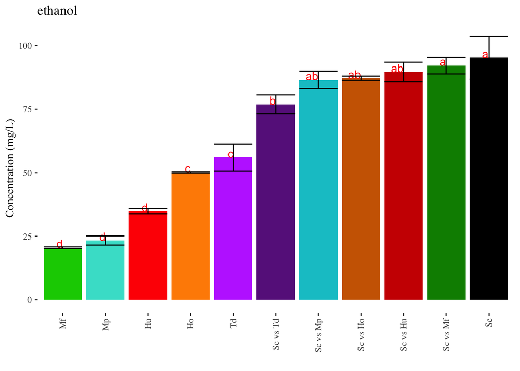

```
## [1] "############  alpha  ############"
## Analysis of Variance Table
##
## Response: metabolite
##           Df   Sum Sq   Mean Sq F value   Pr(>F)
## Species   10 0.072676 0.0072676  3.4127 0.007825 **
## Blocs      4 0.008550 0.0021375  1.0037 0.426761
## Residuals 22 0.046850 0.0021295
## ---
## Signif. codes:  0 '***' 0.001 '**' 0.01 '*' 0.05 '.' 0.1 ' ' 1
##
##
## Species     metabolite    std    ymin   ymax  groups
## ---------  -----------  -----  ------  -----  -------
## Ho                0.09   0.10   -0.01   0.19  ab
## Hu                0.14   0.09    0.05   0.22  ab
## Mf                0.10   0.00    0.10   0.10  ab
## Mp                0.13   0.01    0.12   0.14  ab
## Sc                0.08   0.04    0.05   0.12  ab
## Sc vs Ho          0.03   0.00    0.03   0.03  b
## Sc vs Hu          0.09   0.06    0.03   0.15  ab
## Sc vs Mf          0.08   0.01    0.08   0.09  ab
## Sc vs Mp          0.19   0.01    0.19   0.20  a
## Sc vs Td          0.05   0.03    0.02   0.08  b
## Td                0.02   0.01    0.01   0.03  b
```

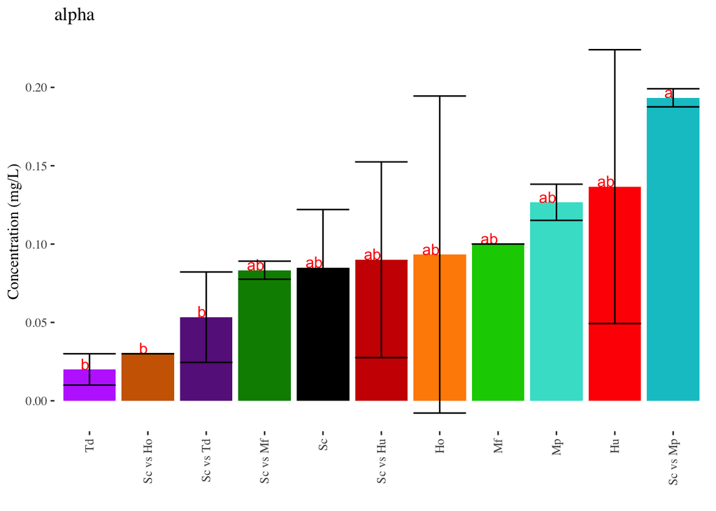

```
## [1] "############  succinate  ############"
## Analysis of Variance Table
##
## Response: metabolite
##           Df  Sum Sq  Mean Sq F value    Pr(>F)
## Species   10 2.59404 0.259404 25.3771 8.393e-10 ***
## Blocs      4 0.35205 0.088013  8.6101 0.0002434 ***
## Residuals 22 0.22488 0.010222
## ---
## Signif. codes:  0 '***' 0.001 '**' 0.01 '*' 0.05 '.' 0.1 ' ' 1
##
##
## Species     metabolite    std   ymin   ymax  groups
## ---------  -----------  -----  -----  -----  -------
## Ho                0.35   0.00   0.35   0.35  b
## Hu                0.66   0.03   0.63   0.69  b
## Mf                0.29   0.01   0.28   0.29  b
## Mp                0.26   0.03   0.24   0.29  b
## Sc                1.05   0.28   0.77   1.33  a
## Sc vs Ho          0.42   0.04   0.38   0.46  b
## Sc vs Hu          0.60   0.06   0.54   0.65  b
## Sc vs Mf          0.58   0.02   0.56   0.60  b
## Sc vs Mp          0.52   0.04   0.48   0.55  b
## Sc vs Td          0.63   0.06   0.57   0.68  b
## Td                0.42   0.04   0.38   0.45  b
```

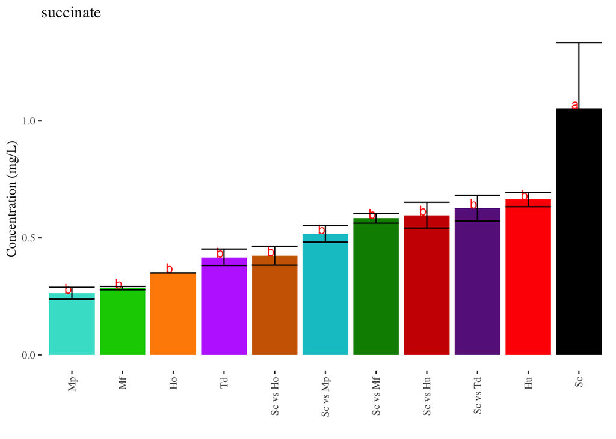

```
## [1] "############  pyruvate  ############"
## Analysis of Variance Table
##
## Response: metabolite
##           Df   Sum Sq   Mean Sq F value   Pr(>F)
## Species   10 0.118298 0.0118298  4.1853 0.002452 **
## Blocs      4 0.031600 0.0079000  2.7950 0.051253 .
## Residuals 22 0.062183 0.0028265
## ---
## Signif. codes:  0 '***' 0.001 '**' 0.01 '*' 0.05 '.' 0.1 ' ' 1
##
##
## Species     metabolite    std   ymin   ymax  groups
## ---------  -----------  -----  -----  -----  -------
## Ho                0.13   0.05   0.08   0.18  ab
## Hu                0.17   0.04   0.14   0.21  ab
## Mf                0.11   0.01   0.10   0.11  b
## Mp                0.29   0.04   0.25   0.33  a
## Sc                0.12   0.08   0.05   0.20  b
## Sc vs Ho          0.08   0.00   0.08   0.08  b
## Sc vs Hu          0.16   0.04   0.12   0.20  ab
## Sc vs Mf          0.12   0.01   0.12   0.13  b
## Sc vs Mp          0.24   0.01   0.23   0.25  ab
## Sc vs Td          0.20   0.12   0.08   0.32  ab
## Td                0.14   0.06   0.08   0.20  ab
```

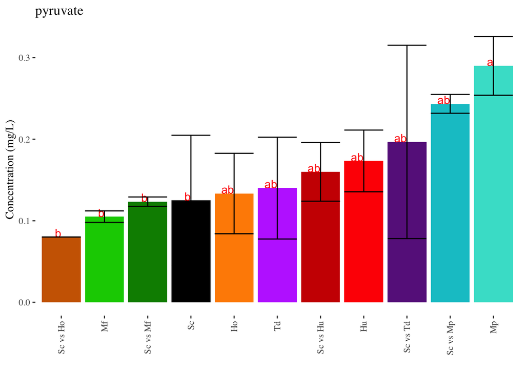

```r
stock.prod <- NULL
for(i in unique(mydata.hplc$Blocs)){
    sub.data.1 <- mydata.hplc %>% filter(Blocs == i)
    for(j in unique(sub.data.1$Fermenter)){
        sub.data <- sub.data.1 %>%
            filter(Fermenter == j) %>%
            filter(Time == max(Time)) %>%
            mutate(sucre.cons = 200 - glucose - fructose) %>%
            select(Blocs, Species, glycerol, acetate, ethanol, alpha, succinate, pyruvate, sucre.cons)

       stock.prod <- rbind.data.frame(stock.prod,sub.data)
    }
}


for(i in 3:8){
    sub.data <- stock.prod %>%
        select(c(Blocs = 1, Species = 2, metabolite = i))


    metabolite.aov <- aov(metabolite~Species,data = sub.data)
    metabolite.tukey <- HSD.test(metabolite.aov,"Species")

    print(paste("############ ",colnames(stock.prod)[i]," ############"))
    print(anova(lm(metabolite~Species+Blocs,sub.data)))

    means.metabolite <- metabolite.tukey$means %>%
        select(metabolite,std) %>%
        mutate(ymin = metabolite - std, ymax = metabolite + std)
    means.metabolite$Species <- row.names(metabolite.tukey$means)
    groups.metabolite <- metabolite.tukey$groups
    groups.metabolite$Species <- rownames(groups.metabolite)

    means.metabolite <- left_join(means.metabolite,groups.metabolite, by = "Species") %>%
        select(Species,metabolite = metabolite.x, std, ymin, ymax, groups)
    means.metabolite$Species <- factor(means.metabolite$Species, levels = c( "Ho","Sc vs Ho", "Hu","Sc vs Hu", "Mf", "Sc vs Mf","Mp","Sc vs Mp","Td","Sc vs Td",  "Sc"))


    print(knitr::kable(means.metabolite, digits = 2))

    g.metabolite <- means.metabolite %>%
        ggplot(aes(x = reorder(Species,metabolite),, y = metabolite, ymin = ymin, ymax = ymax, label = groups,fill = Species)) +
        geom_bar(stat = "identity") +
        geom_text(col = "red",vjust = 0, hjust = 1) +
        geom_errorbar() +
        scale_fill_manual(values = c("darkorange","darkorange3","red","red3","green3","green4","turquoise","turquoise3","darkorchid1","darkorchid4","black")) +
        theme_tufte() +
        labs(x = "", y = "Concentration (mg/L)", title = colnames(stock.prod)[i]) +
        theme(axis.text.x = element_text(angle = 90, hjust = 1, vjust = 0.5), legend.position='none')
    print(g.metabolite)

}
```

# Yield relative to S. cerevisiae Yield

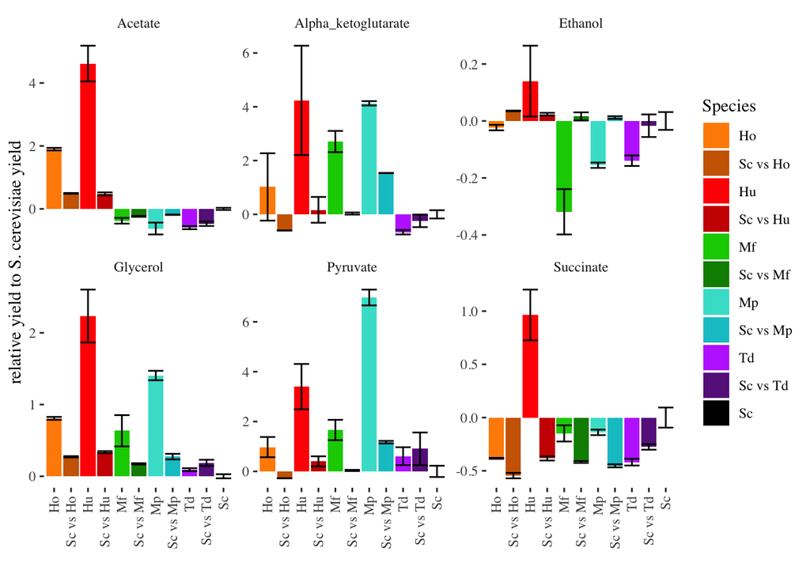

```r
myyield <- stock.prod %>%
    mutate(Glycerol = glycerol/sucre.cons,
           Acetate = acetate/sucre.cons,
           Ethanol = ethanol/sucre.cons,
           Alpha_ketoglutarate = alpha/sucre.cons,
           Succinate = succinate/sucre.cons,
           Pyruvate = pyruvate/sucre.cons) %>%
    select(Blocs, Species,Glycerol,Acetate,Ethanol,Alpha_ketoglutarate,Succinate,Pyruvate)


tabgather <- myyield  %>%
    gather(key = parametres, val = value,-Species,-Blocs)


mean.Sc <- tabgather %>%
    filter(Species == "Sc") %>%
    group_by(parametres) %>%
    dplyr::summarise(mean = mean(value))

tabgather$value.r <- 0
for(i in 1:nrow(tabgather)){
    tabgather$value.r[i] <- (tabgather$value[i]-mean.Sc$mean[mean.Sc$parametres == tabgather$parametres[i]])/mean.Sc$mean[mean.Sc$parametres == tabgather$parametres[i]]

}

tabgather %>%
    group_by(Species,parametres) %>%
    dplyr::summarise(mean=mean(value.r),sdt = erreur.std(value.r)) %>%
    mutate(ymin = mean - sdt, ymax = mean + sdt) %>%
    ggplot(aes(x = Species, y = mean, ymin = ymin, ymax = ymax, fill = Species)) +
    geom_bar(stat="identity") +
    geom_errorbar() +
    scale_fill_manual(values = c("darkorange","darkorange3","red","red3","green3","green4","turquoise","turquoise3","darkorchid1","darkorchid4","black")) +
    facet_wrap(~parametres,scales = "free_y") +
    theme_tufte() +
    theme(axis.text.x = element_text(angle = 90,hjust = 1, vjust = 0.5)) +
    labs(x = "", y = "relative yield to S. cerevisiae yield")
```

```
## [1] "############  NA  ############"
## Analysis of Variance Table
##
## Response: value.r
##           Df  Sum Sq Mean Sq F value    Pr(>F)
## Species   10 15.3057 1.53057 34.9146 3.466e-11 ***
## Blocs      4  0.0453 0.01132  0.2583    0.9015
## Residuals 22  0.9644 0.04384
## ---
## Signif. codes:  0 '***' 0.001 '**' 0.01 '*' 0.05 '.' 0.1 ' ' 1
##
##
## Species     value.r    std    ymin   ymax  groups
## ---------  --------  -----  ------  -----  -------
## Ho             0.81   0.03    0.77   0.84  c
## Hu             2.23   0.64    1.60   2.87  a
## Mf             0.63   0.31    0.33   0.94  cd
## Mp             1.40   0.11    1.29   1.52  b
## Sc             0.00   0.08   -0.08   0.08  e
## Sc vs Ho       0.27   0.02    0.26   0.29  cde
## Sc vs Hu       0.34   0.03    0.31   0.36  cde
## Sc vs Mf       0.17   0.02    0.16   0.19  de
## Sc vs Mp       0.27   0.07    0.21   0.34  cde
## Sc vs Td       0.19   0.07    0.11   0.26  de
## Td             0.09   0.04    0.06   0.13  de
```

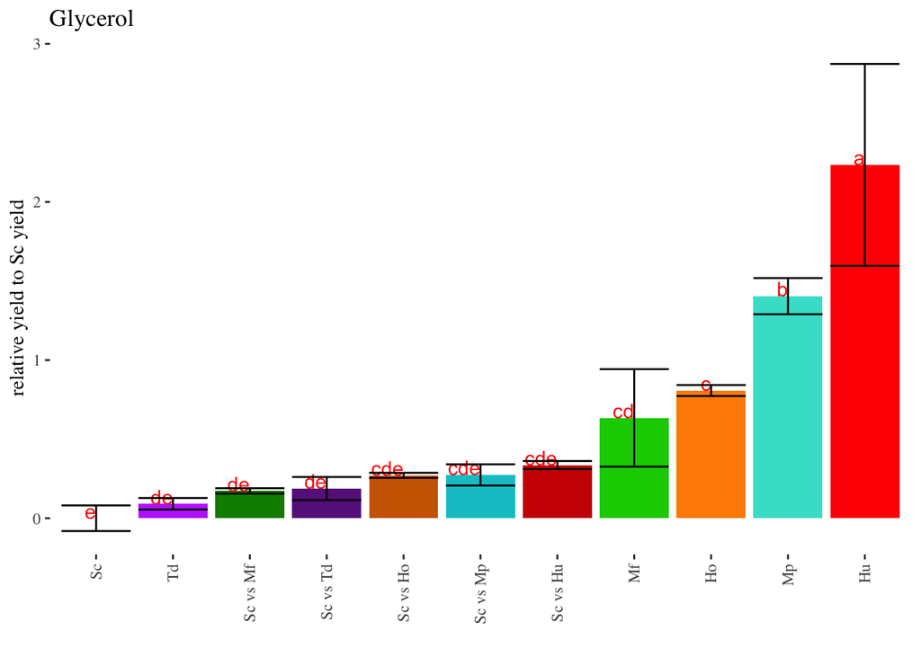

```
## [1] "############  NA  ############"
## Analysis of Variance Table
##
## Response: value.r
##           Df Sum Sq Mean Sq F value    Pr(>F)
## Species   10 73.240  7.3240 71.5033 2.048e-14 ***
## Blocs      4  0.045  0.0113  0.1105    0.9775
## Residuals 22  2.253  0.1024
## ---
## Signif. codes:  0 '***' 0.001 '**' 0.01 '*' 0.05 '.' 0.1 ' ' 1
##
##
## Species     value.r    std    ymin    ymax  groups
## ---------  --------  -----  ------  ------  -------
## Ho             1.90   0.07    1.83    1.97  b
## Hu             4.62   0.98    3.63    5.60  a
## Mf            -0.38   0.13   -0.50   -0.25  cd
## Mp            -0.62   0.33   -0.95   -0.30  d
## Sc             0.00   0.10   -0.10    0.10  cd
## Sc vs Ho       0.49   0.02    0.47    0.51  c
## Sc vs Hu       0.48   0.08    0.39    0.56  c
## Sc vs Mf      -0.24   0.02   -0.26   -0.21  cd
## Sc vs Mp      -0.19   0.01   -0.20   -0.17  cd
## Sc vs Td      -0.47   0.12   -0.59   -0.35  d
## Td            -0.60   0.09   -0.68   -0.51  d
```

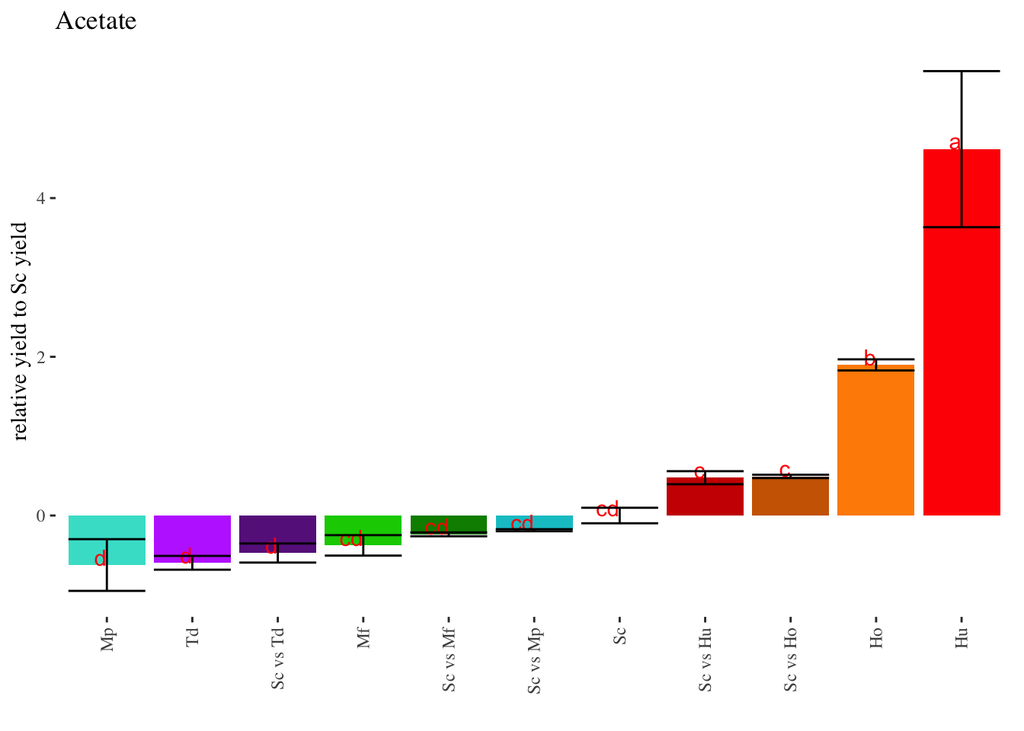

```
## [1] "############  NA  ############"
## Analysis of Variance Table
##
## Response: value.r
##           Df  Sum Sq  Mean Sq F value    Pr(>F)
## Species   10 0.37706 0.037706  6.7145 0.0001016 ***
## Blocs      4 0.05043 0.012608  2.2452 0.0969853 .
## Residuals 22 0.12354 0.005616
## ---
## Signif. codes:  0 '***' 0.001 '**' 0.01 '*' 0.05 '.' 0.1 ' ' 1
##
##
## Species     value.r    std    ymin    ymax  groups
## ---------  --------  -----  ------  ------  -------
## Ho            -0.02   0.02   -0.04   -0.01  ab
## Hu             0.14   0.21   -0.07    0.36  a
## Mf            -0.32   0.11   -0.43   -0.21  c
## Mp            -0.16   0.02   -0.17   -0.14  bc
## Sc             0.00   0.09   -0.09    0.09  ab
## Sc vs Ho       0.04   0.00    0.03    0.04  ab
## Sc vs Hu       0.02   0.01    0.02    0.03  ab
## Sc vs Mf       0.02   0.02   -0.01    0.04  ab
## Sc vs Mp       0.01   0.01    0.00    0.02  ab
## Sc vs Td      -0.02   0.07   -0.09    0.05  ab
## Td            -0.14   0.03   -0.17   -0.11  bc
```

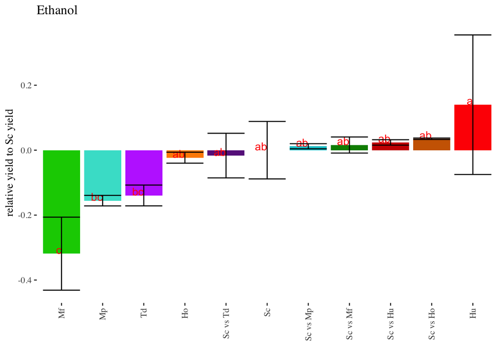

```
## [1] "############  NA  ############"
## Analysis of Variance Table
##
## Response: value.r
##           Df  Sum Sq Mean Sq F value    Pr(>F)
## Species   10 100.818 10.0818  6.0942 0.0002057 ***
## Blocs      4   1.181  0.2952  0.1784 0.9471344
## Residuals 22  36.395  1.6543
## ---
## Signif. codes:  0 '***' 0.001 '**' 0.01 '*' 0.05 '.' 0.1 ' ' 1
##
##
## Species     value.r    std    ymin    ymax  groups
## ---------  --------  -----  ------  ------  -------
## Ho             1.02   2.17   -1.15    3.19  ab
## Hu             4.24   3.52    0.72    7.76  a
## Mf             2.71   0.56    2.15    3.27  ab
## Mp             4.13   0.14    3.99    4.27  a
## Sc             0.00   0.44   -0.44    0.44  b
## Sc vs Ho      -0.60   0.00   -0.60   -0.60  b
## Sc vs Hu       0.17   0.83   -0.66    1.00  b
## Sc vs Mf       0.03   0.07   -0.04    0.10  b
## Sc vs Mp       1.54   0.01    1.53    1.55  ab
## Sc vs Td      -0.24   0.41   -0.65    0.16  b
## Td            -0.66   0.14   -0.81   -0.52  b
```

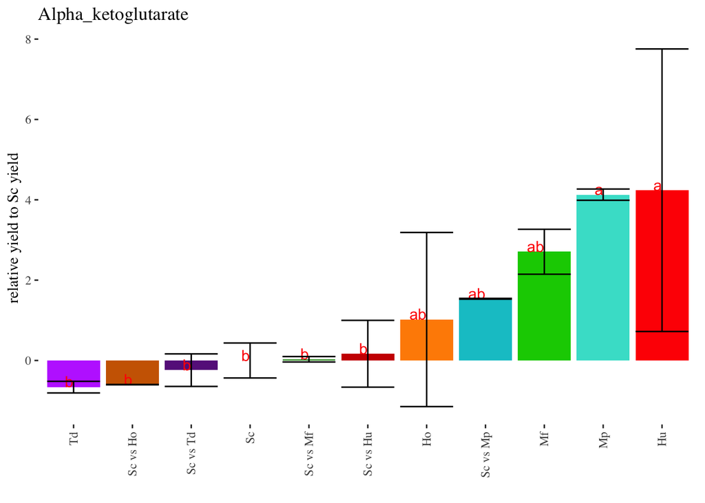

```
## [1] "############  NA  ############"
## Analysis of Variance Table
##
## Response: value.r
##           Df Sum Sq Mean Sq F value    Pr(>F)
## Species   10 5.4334 0.54334 21.5215 4.179e-09 ***
## Blocs      4 0.3161 0.07901  3.1297   0.03516 *
## Residuals 22 0.5554 0.02525
## ---
## Signif. codes:  0 '***' 0.001 '**' 0.01 '*' 0.05 '.' 0.1 ' ' 1
##
##
## Species     value.r    std    ymin    ymax  groups
## ---------  --------  -----  ------  ------  -------
## Ho            -0.38   0.01   -0.39   -0.38  bc
## Hu             0.96   0.41    0.55    1.38  a
## Mf            -0.15   0.11   -0.26   -0.04  bc
## Mp            -0.14   0.05   -0.18   -0.09  bc
## Sc             0.00   0.27   -0.27    0.27  b
## Sc vs Ho      -0.55   0.04   -0.59   -0.50  c
## Sc vs Hu      -0.38   0.03   -0.42   -0.35  bc
## Sc vs Mf      -0.42   0.02   -0.43   -0.40  bc
## Sc vs Mp      -0.45   0.03   -0.48   -0.43  c
## Sc vs Td      -0.28   0.04   -0.32   -0.23  bc
## Td            -0.42   0.05   -0.47   -0.36  bc
```

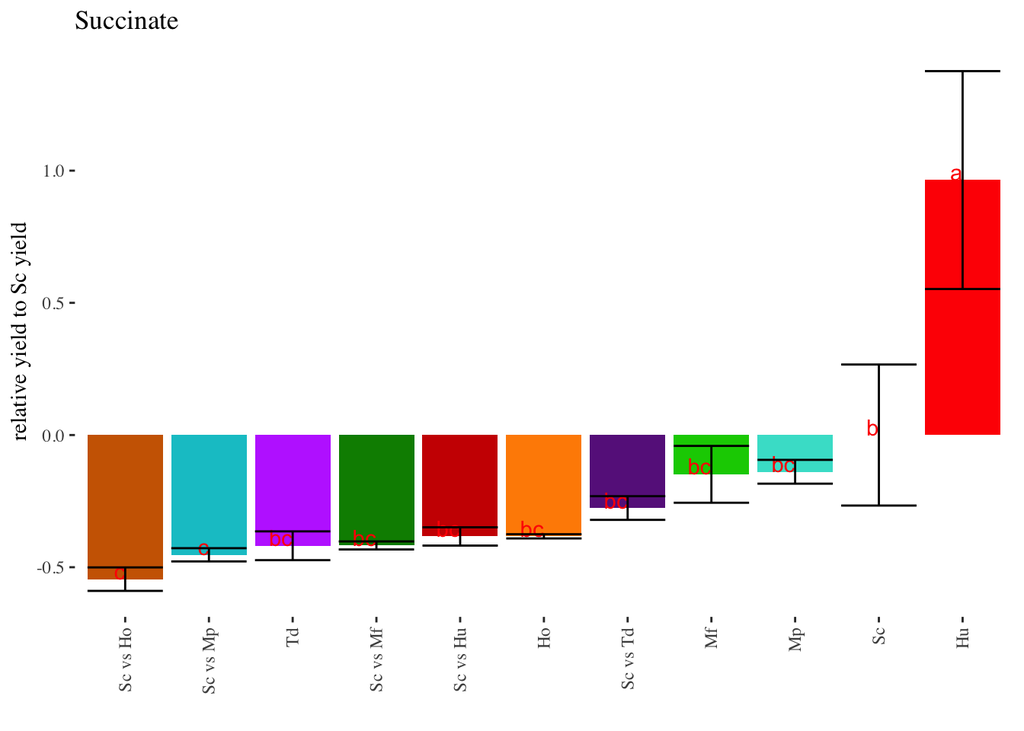

```
## [1] "############  NA  ############"
## Analysis of Variance Table
##
## Response: value.r
##           Df  Sum Sq Mean Sq F value    Pr(>F)
## Species   10 140.453  14.045 27.2219 4.199e-10 ***
## Blocs      4   2.020   0.505  0.9787    0.4393
## Residuals 22  11.351   0.516
## ---
## Signif. codes:  0 '***' 0.001 '**' 0.01 '*' 0.05 '.' 0.1 ' ' 1
##
##
## Species     value.r    std    ymin    ymax  groups
## ---------  --------  -----  ------  ------  -------
## Ho             0.97   0.70    0.27    1.68  c
## Hu             3.40   1.58    1.82    4.97  b
## Mf             1.66   0.58    1.08    2.24  bc
## Mp             6.98   0.55    6.43    7.52  a
## Sc             0.00   0.64   -0.64    0.64  c
## Sc vs Ho      -0.28   0.01   -0.28   -0.27  c
## Sc vs Hu       0.40   0.35    0.05    0.75  c
## Sc vs Mf       0.04   0.04   -0.01    0.08  c
## Sc vs Mp       1.17   0.09    1.08    1.26  c
## Sc vs Td       0.90   1.14   -0.23    2.04  c
## Td             0.61   0.62   -0.02    1.23  c
```

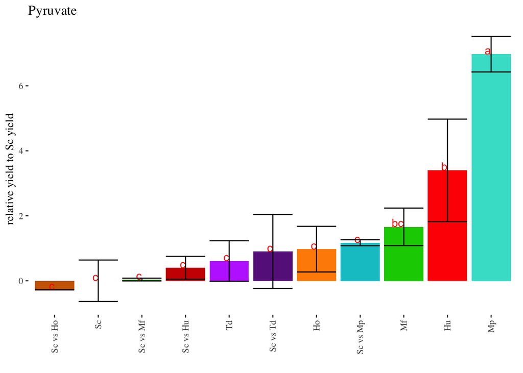

```r
for(i in unique(tabgather$parametres)){
    sub.data <- tabgather %>%
        filter(parametres == i)


    relative.yield.aov <- aov(value.r~Species,data = sub.data)
    relative.yield.tukey <- HSD.test(relative.yield.aov,"Species")

    print(paste("############ ",colnames(stock.prod)[i]," ############"))
    print(anova(lm(value.r~Species+Blocs,sub.data)))

    means.relative.yield <- relative.yield.tukey$means %>%
        select(value.r,std) %>%
        mutate(ymin = value.r - std, ymax = value.r + std)
    means.relative.yield$Species <- row.names(relative.yield.tukey$means)
    groups.relative.yield <- relative.yield.tukey$groups
    groups.relative.yield$Species <- rownames(groups.relative.yield)

    means.relative.yield <- left_join(means.relative.yield,groups.relative.yield, by = "Species") %>%
        select(Species,value.r = value.r.x, std, ymin, ymax, groups)
    means.relative.yield$Species <- factor(means.relative.yield$Species, levels = c( "Ho","Sc vs Ho", "Hu","Sc vs Hu", "Mf", "Sc vs Mf","Mp","Sc vs Mp","Td","Sc vs Td",  "Sc"))


    print(knitr::kable(means.relative.yield, digits = 2))

    g.relative.yield <- means.relative.yield %>%
        ggplot(aes(x = reorder(Species,value.r), y = value.r, ymin = ymin, ymax = ymax, label = groups,fill = Species)) +
        geom_bar(stat = "identity") +
        geom_text(col = "red",vjust = 0, hjust = 1) +
        geom_errorbar() +
        scale_fill_manual(values = c("darkorange","darkorange3","red","red3","green3","green4","turquoise","turquoise3","darkorchid1","darkorchid4","black")) +
        theme_tufte() +
        labs(x = "", y = "relative yield to Sc yield", title = i) +
        theme(axis.text.x = element_text(angle = 90, hjust = 1, vjust = 0.5), legend.position='none')
    print(g.relative.yield)
}
```